# modelo_LSTM

aire analytics

September 2, 2018

```r
#estaciones de calidad del Ayuntamiento de Madrid
#28079004 Pl España
#28079049 Retiro
estaciones_calidad_activas <- c('28079004','28079049')
```

```r
data <- read.csv2('28079004datos.csv', header = TRUE, sep = ',')
```

eliminamos NA

```r
data <- data[!is.na(data$cont8),]
```

eliminamos la columna X

```r
data <- data[,c('fecha','est3491','est6809','est4451','est4138','prec','presMax','presMin','racha',
                'velmedia','tmax','tmed','tmin','cont8')]
```

se selecciona el tipo de cada dato

```r
data$fecha <- as.Date(data$fecha)
data$est3491 <- as.numeric(data$est3491)
data$est6809 <- as.numeric(data$est6809)
data$est4451 <- as.numeric(data$est4451)
data$est4138 <- as.numeric(data$est4138)
data$prec <- as.numeric(data$prec)
data$presMax <- as.numeric(data$presMax)
data$presMin <- as.numeric(data$presMin)
data$racha <- as.numeric(data$racha)
data$velmedia <- as.numeric(data$velmedia)
data$tmax <- as.numeric(data$tmax)
data$tmed <- as.numeric(data$tmed)
data$tmin <- as.numeric(data$tmin)
data$cont8 <- as.numeric(data$cont8)
```

```r
data$est3491_2 <-NA[]
data$est6809_2 <-NA[]
data$est4451_2 <-NA[]
data$est4138_2 <-NA[]
data$est3491_3 <-NA[]
data$est6809_3 <-NA[]
data$est4451_3 <-NA[]
data$est4138_3 <-NA[]
data$est3491_4 <-NA[]
data$est6809_4 <-NA[]
data$est4451_4 <-NA[]
data$est4138_4 <-NA[]
data$prec_2 <- NA[]
data$prec_3 <- NA[]
data$prec_4 <- NA[]
data$vel_2 <- NA[]
data$vel_3 <- NA[]
data$vel_4 <- NA[]
data$presMax_2 <- NA[]
data$presMax_3 <- NA[]
data$presMax_4 <- NA[]
data$presMin_2 <- NA[]
data$presMin_3 <- NA[]
data$presMin_4 <- NA[]
data$cont_2 <- NA[]
```

```r
for (i in (5:nrow(data))){
  data$est3491_2[i] <- as.numeric(data$est3491[i-2])
  data$est6809_2[i] <- as.numeric(data$est6809[i-2])
  data$est4451_2[i] <- as.numeric(data$est4451[i-2])
  data$est4138_2[i] <- as.numeric(data$est4138[i-2])
  data$est3491_3[i] <- as.numeric(data$est3491[i-3])
  data$est6809_3[i] <- as.numeric(data$est6809[i-3])
  data$est4451_3[i] <- as.numeric(data$est4451[i-3])
  data$est4138_3[i] <- as.numeric(data$est4138[i-3])
  data$est3491_4[i] <- as.numeric(data$est3491[i-4])
  data$est6809_4[i] <- as.numeric(data$est6809[i-4])
  data$est4451_4[i] <- as.numeric(data$est4451[i-4])
  data$est4138_4[i] <- as.numeric(data$est4138[i-4])
  data$prec_2[i] <- as.numeric(data$prec[i-2])
  data$prec_3[i] <- as.numeric(data$prec[i-3])
  data$prec_4[i] <- as.numeric(data$prec[i-4])
  data$vel_2[i] <- as.numeric(data$velmedia[i-2])
  data$vel_3[i] <- as.numeric(data$velmedia[i-3])
  data$vel_4[i] <- as.numeric(data$velmedia[i-4])
  data$presMax_2[i] <- as.numeric(data$presMax[i-2])
  data$presMax_3[i] <- as.numeric(data$presMax[i-3])
  data$presMax_4[i] <- as.numeric(data$presMax[i-4])
  data$presMin_2[i] <- as.numeric(data$presMin[i-2])
  data$presMin_3[i] <- as.numeric(data$presMin[i-3])
  data$presMin_4[i] <- as.numeric(data$presMin[i-4])
  data$cont_2[i] <- as.numeric(data$cont8[i-2])
}
```

Vamos a realizar la predicción sobrel el incremento de contaminación, por lo tanto lo que hacemos es generar una nueva variable que indica el incremento del contaminante sobre los dos días anteriores

```r
data$incremento <-NA[]
```

```r
for (i in (3:nrow(data))){
  data$incremento[i] <- as.numeric(data$cont8[i]) - as.numeric(data$cont8[i-2])
}
```

normalizamos los datos eliminando las filas que no tiene incremento y no tienen tráfico acumulado

```r
dataNuevo <- data[!is.na(data$vel_4),]
dataNorm <- scale(dataNuevo[,2:40])
```

```r
datos = cor(dataNorm)
#print(datos)
```

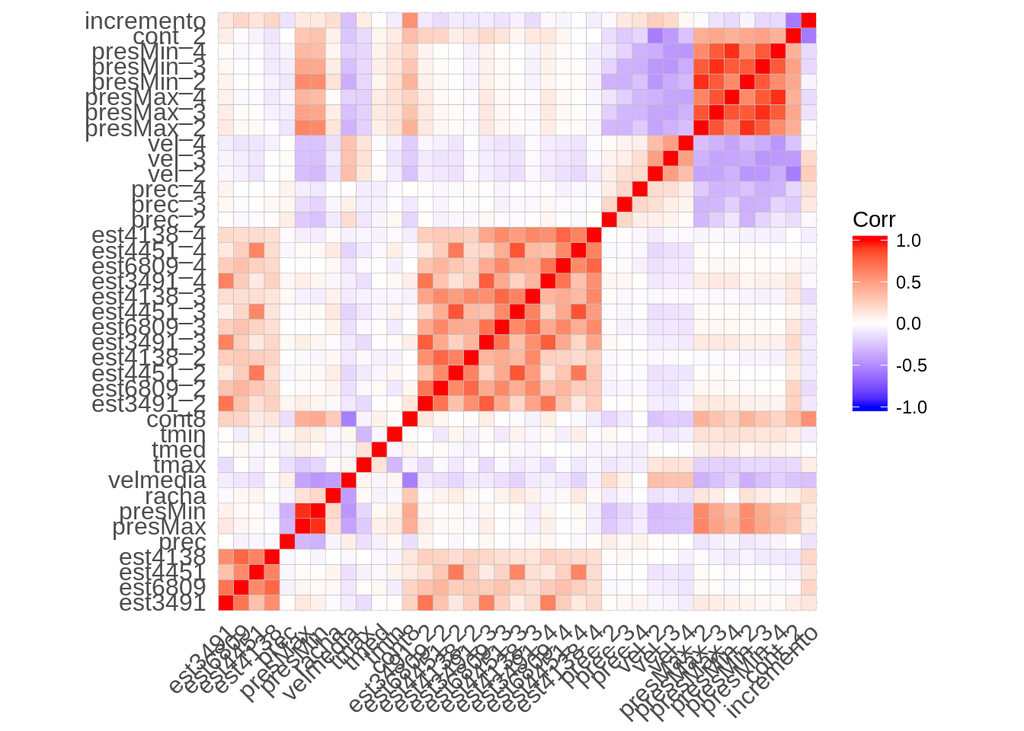

```r
library(ggcorrplot)
ggcorrplot(datos)
```

creamos una matriz con los datos normalizados que influyen en la contaminacion y nos quedamos con el incremento de contaminante

```r
dataModelo <- dataNorm[, c('est3491_2','est6809_2','est4451_2','est4138_2','est3491_3','est6809_3','est4451_3','est4138_3',
                           'est3491_4','est6809_4','est4451_4','est4138_4','prec_2','prec_3','prec_4',
                           'vel_2','vel_3','vel_4', 'presMax_2','presMax_3','presMax_4',
                           'presMin_2','presMin_3','presMin_4','cont_2','incremento')]
```

se añade la fecha

```r
dataModelo <- cbind(as.Date(dataNuevo$fecha), dataModelo)
```

```r
colnames(dataModelo)[1] <- 'fecha'
```

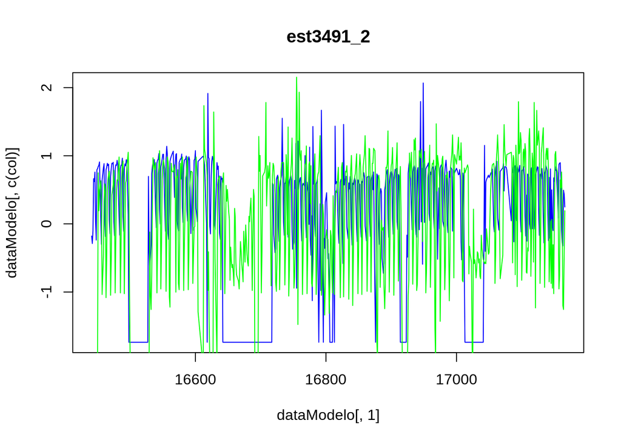

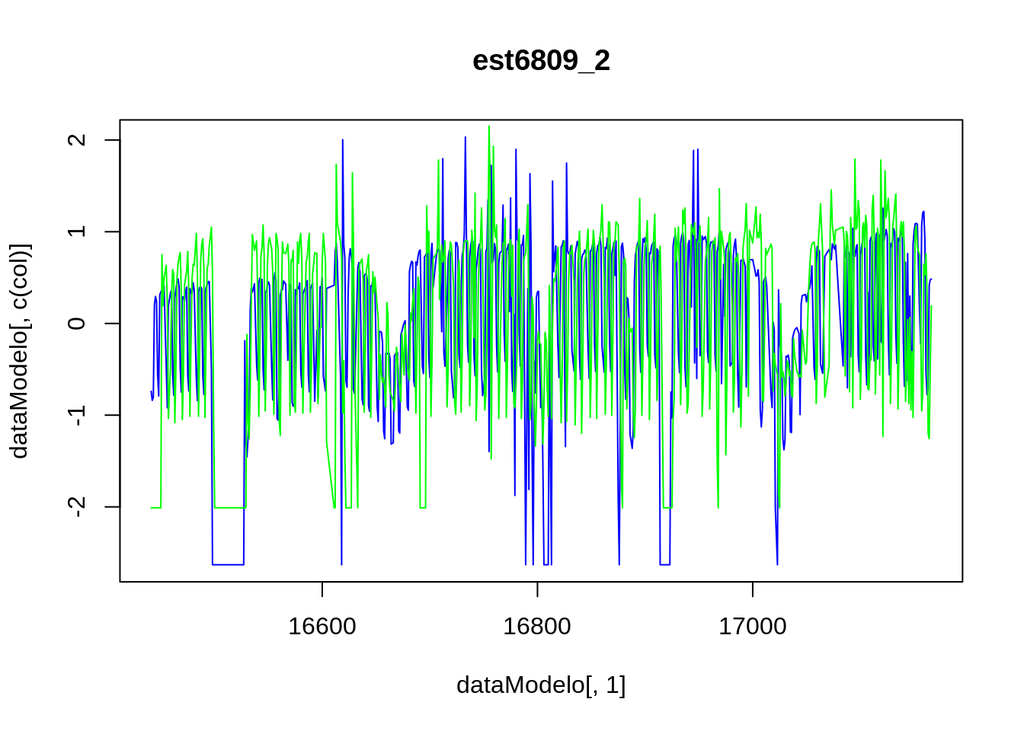

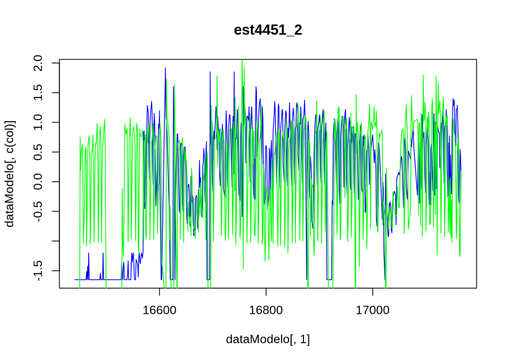

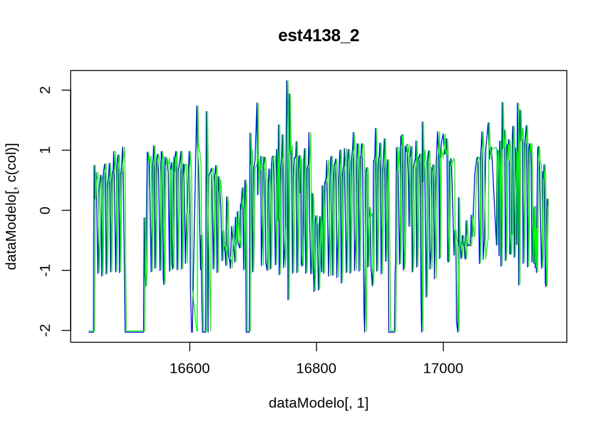

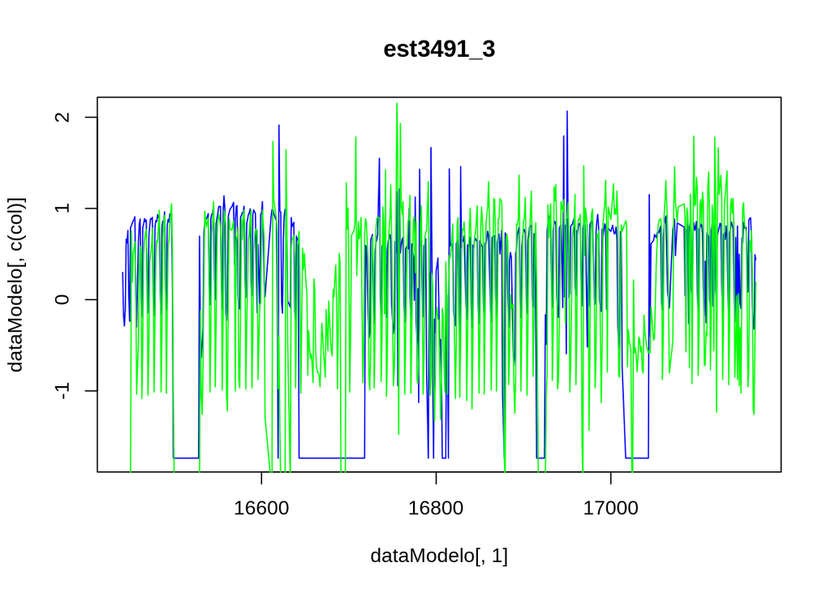

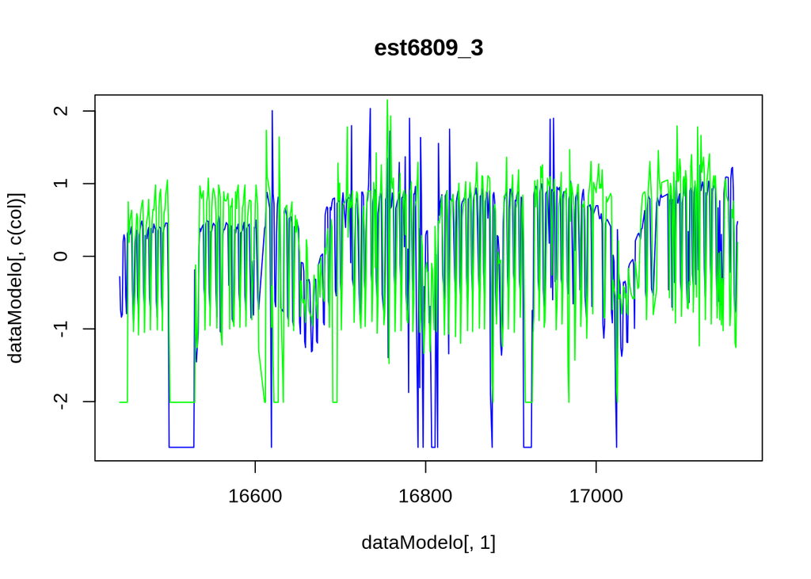

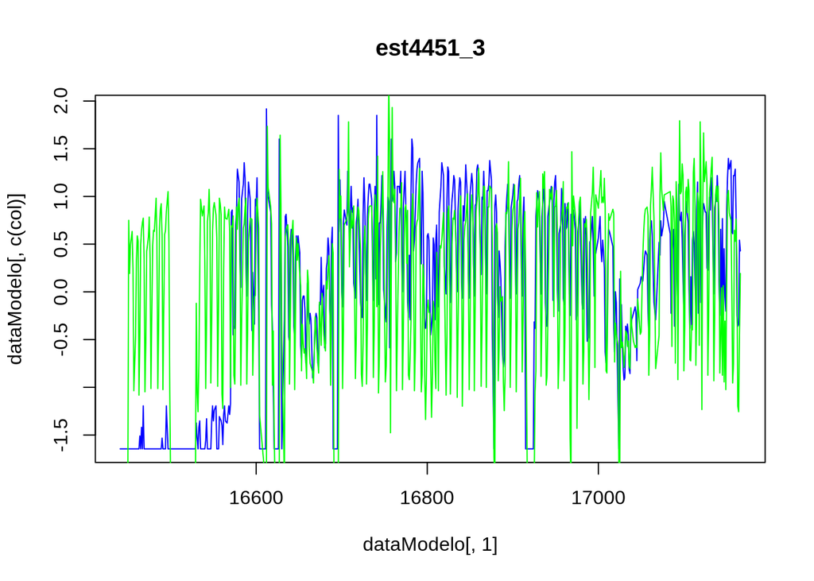

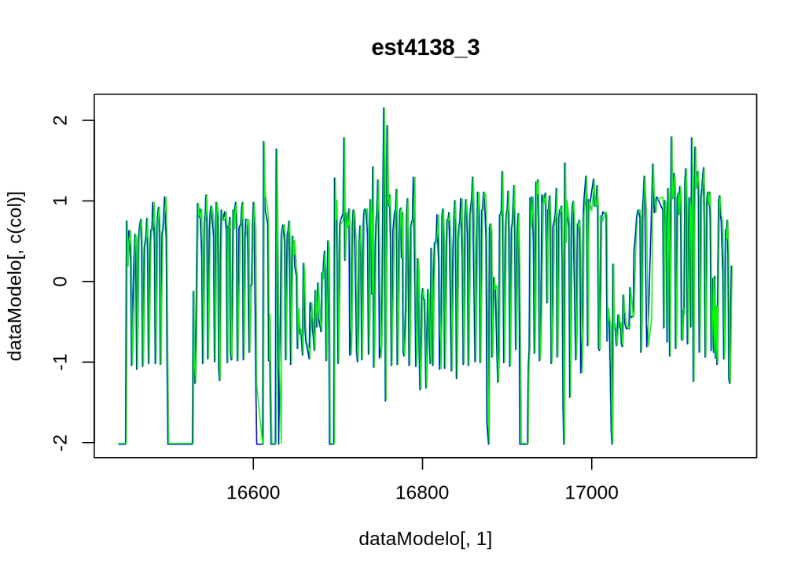

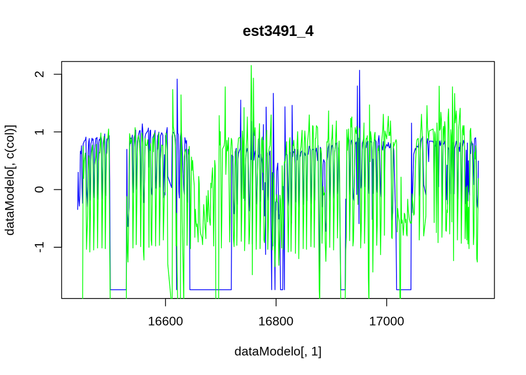

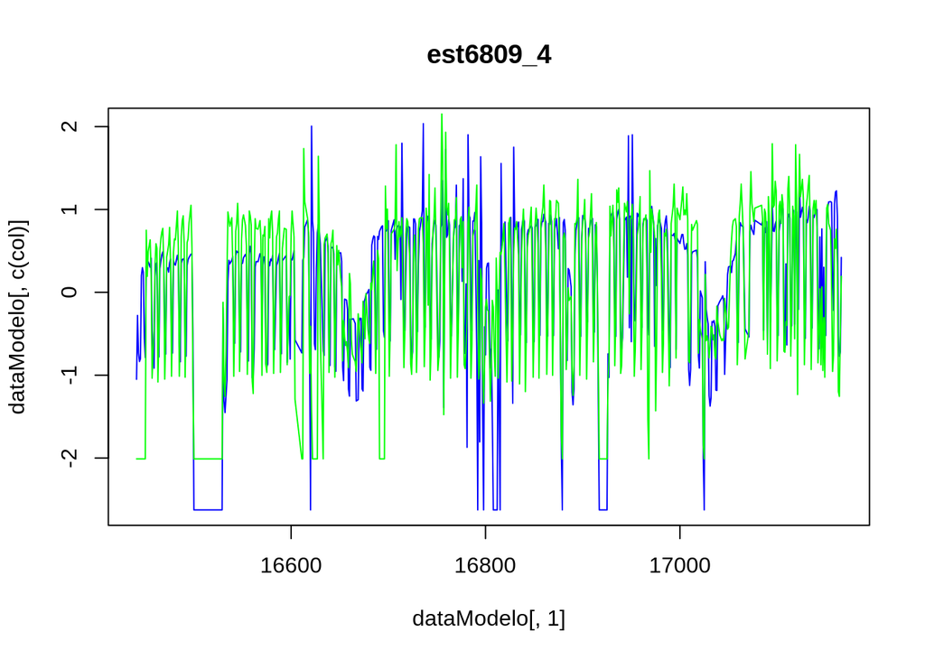

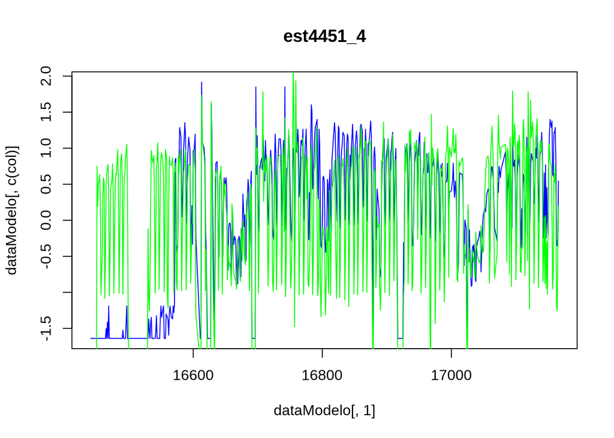

```r
for (col in (2:12)){
  plot(x=dataModelo[,1], y=dataModelo[,c(col)], type = "l", main = colnames(dataModelo)[col], col='blue')
  lines(x=dataModelo[,1], y=dataModelo[,13], col='green')
}
```

```r
library(ROCR)
library(caTools)
```

Sobre el Dataset de datos históricos vamos a construir un modelo que permita la prediccións. Para poder construir un modelo necesitamos contar con un conjunto de datos de entrenamiento que nos permitan aprender los patrones incluidos en los datos. Para seleccionar entre los modelos y poder asegurar que los patrones aprendidos son generalizables necesitamos valorar nuestros modelos en un conjunto de validación.

Por último debemos contar con un conjunto de test que nos permita establecer la capacidad predictiva del modelo elegido, este conjunto no debe utilizarse durante el proceso de construcción y validacion del modelo.

Primero se divide el conjunto total en dos conjuntos:

```r
dfModelo <- data.frame(dataModelo)
set.seed(1234)
n <- nrow(dfModelo)
muestra  <- sample(n, n * .70)
train    <- dfModelo[muestra, ]
test     <- dfModelo[-muestra, ]
```

De forma que tenemos 2 conjuntos train y test

```r
dim(dfModelo)
```

```
## [1] 639  27
```

```r
dim(train)
```

```
## [1] 447  27
```

```r
dim(test)
```

```
## [1] 192  27
```

### Bloque de Construcción de Modelos

```r
#modelo de regresión lineal múltiple
modelo <- lm(formula = 'incremento ~ est3491_2 + est6809_2 + est4451_2 + est4138_2 + est3491_3 + est6809_3 + est4451_3 + est4138_3 +
             est3491_4 + est6809_4 + est4451_4 + est4138_4 + prec_2 + prec_3 + prec_4 +
             vel_2 + vel_3 + vel_4 + presMax_2 + presMax_3 + presMax_4 + presMin_2 + presMin_3 + presMin_4 + cont_2' ,data=train)
```

Ahora vamos a verificar si hace una predicción correcta

```r
prediccionLM   <- predict(modelo, test[,1:26])
```

```r
resultado <- data.frame(real = test[,27], prediccion = prediccionLM)
resultado
```

```
##            real  prediccion
## 8    0.43900529 -0.22511739
## 9    0.18725264 -0.36979399
## 18   0.08535276  0.27055867
## 22  -1.02355771 -0.66617902
## 24   0.53491106 -0.02709650
## 25   0.78666370  0.22007293
## 31  -1.37121613 -0.51025585
## 36   0.22321730  0.01896707
## 38   0.88856358  0.48843381
## 39  -0.20236455 -0.69689033
## 40  -0.22034688 -0.56801989
## 41   0.73871082  0.17674591
## 43   0.11532331 -0.47090531
## 44  -0.87969905 -0.93739234
```

[output cut: 178 more lines]

Verificamos de forma numérica si la predicción se ajusta al real

```r
resultado$desviacion=((resultado$real-resultado$prediccion)/resultado$real)
precision=1-abs(mean(resultado$desviacion))
precision
```

```
## [1] -0.6940083
```

vemos la suma del error cuadrático que es otro buen indicador

```r
sumsqe <- sum (((resultado$real-resultado$prediccion)^2)/nrow(test))
sumsqe
```

```
## [1] 0.6608703
```

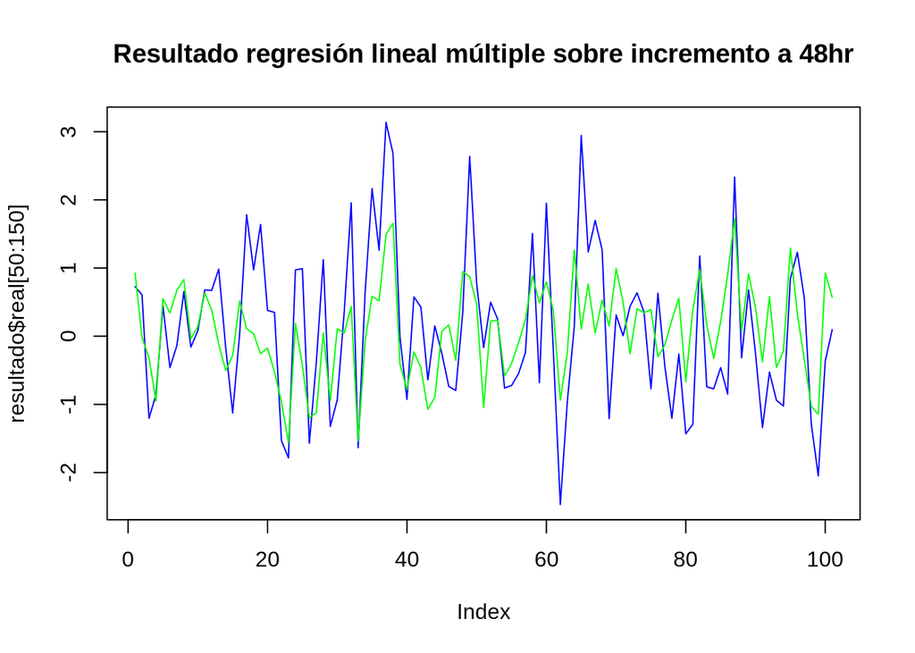

```r
plot(resultado$real[50:150], type = "l", main = "Resultado regresión lineal múltiple sobre incremento a 48hr", col='blue')
lines(resultado$prediccion[50:150], col='green')
```